# Predicting Employee Satisfaction

## Introduction

Companies generate plenty of data on their customers in order to better inform their business decisions. There does not seem to be many analyses conducted on the data of their employees that are publicly available (admittedly, this most likely for privacy reasons). Thanks to resources like Kaggle, I was able to find a data set of employees who work at a particular firm. I apply several machine learning techniques to this data to see how well my models could estimate employee satisfaction at a firm. I also provide some recommendations that I would make to this firm at the end.

## Data Set

Link to data set: https://www.kaggle.com/datasets/redpen12/employees-satisfaction-analysis

This data set from Kaggle is a survey of employees in a particular firm. It contains variables such as salary level, time spent at the company, and most importantly, the satisfaction level. That last variable will be the response variable that I am trying to predict. Since this is going to be a classification problem, our response variable needs to be binary (0 or 1). Lets take the median value of the satisfaction level:

```
## [1] 0.64
```

We can see that the median value of the satisfaction level is 0.64. We can use this median value to create a variable called firm_binary, which takes the satisfaction level of a given employee and makes a comparison to the median satisfaction level. If the satisfaction level of the employee is greater than the median value, the variable will be 1. Otherwise, the variable will be 0. I then set a seed to ensure reproducibility of the models that I plan on running and then I create a 90/10 split of my data. 90% of my data is a training set, and 10% is dedicated to the test set.

After splitting my data, I create dummy variables for the different salary levels and departments that people can work in this company. These dummy variables are essentially quantitative markers that are 1 if true, and 0 if false. So for example, someone can have a dummy variable for working in the marketing department and a dummy variable for a medium level salary. However, an entry can’t have two “activated” dummy variables within a category (Ex: an employee can’t have both a low and a high salary, or work in both marketing and IT).

The last things that I did in regards to preparing the data for analysis was to rework the average monthly hours worked column to average weekly hours worked for better interpretability of my models, remove the columns that I derived the dummy variables from as well as other columns that were not needed, and removed observations that had any missing data. I applied these transformations to both the training set and the test set. After all of that, I was left with 14,999 rows of employee records to work with. Without further adieu, let’s jump into the analysis.

## Analysis

This section is going to be split up in to four parts. I used four different machine learning / statistical learning techniques to estimate how well I was able to predict employee satisfaction. I also visualized some of the results as well. I used these methods:

- K-Nearest Neighbors
- Regression Trees
- Random Forest/Bagging
- XGBoost

## K-nearest Neighbors

The way that KNN works is that it finds the closest data points in the training data to a new data point. Then it assigns a label of the majority class among neighbors to the new data point.

To give a more practical example, lets say that the algorithm comes across a new data point. KNN will use the surrounding data points that are similar to that new entry to essentially vote on what the new data point will be classified as.

The number of neighbors the algorithm uses depends on the $k$ that we pick for it. Rather than picking values at random to hopefully find the best $k$, we can use a process called cross validation. This is a technique that we can use to assess model efficacy. I am using a special kind of cross validation called k-fold cross validation to test how effective different values of $k$ are when it comes to predicting employee satisfaction.

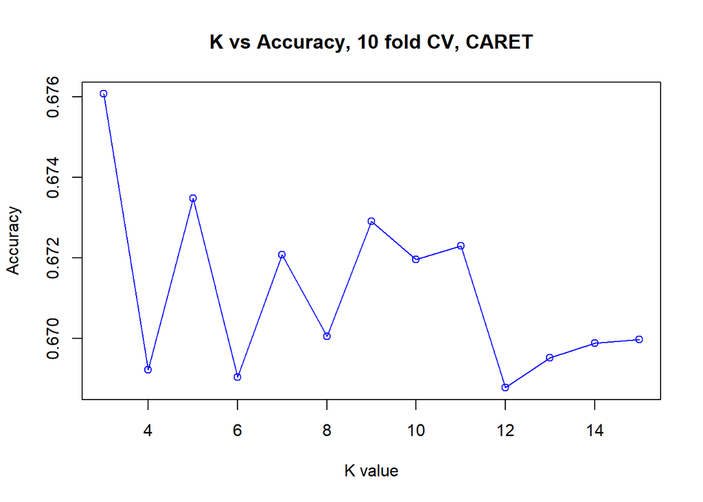

The y-axis is the prediction accuracy and the x-axis is the value of $k$. It appears that when $k$ = 3, the model yields the best prediction accuracy. We can use this information to help create our model. After supplying the model with the response variable that we want to predict, our training data, and value of $k$, we use our trained model to predict the satisfaction level of unseen observations that are in our test set. We can display the results of the model in a confusion matrix:

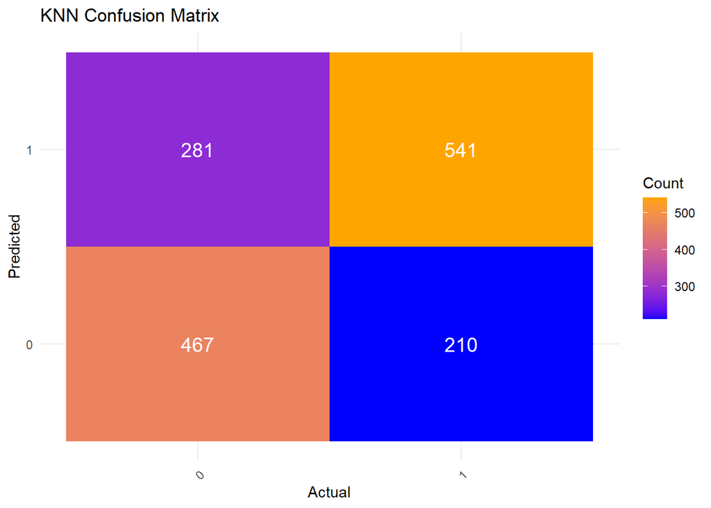

We can see how many data points the model guessed correctly along the main diagonal of the matrix ((0,0), and (1,1)). By adding the values in the main diagonal and dividing by the sum of the numbers in the squares, we can see that the model was able to make correct predictions about 67% of the time. So slightly better than a coin flip. Let’s see how the other models perform.

## Regression Trees

Regression trees are a much simpler method we can use to predict employee satisfaction. This displays our data in a tree like structure and the branches represent splits in our data. The benefit of this is that trees are a much more interpretable machine learning method because we can see how certain parts of our data can be broken down.

```
##
## Classification tree:
## tree(formula = firm_binary ~ ., data = firm_train)
## Variables actually used in tree construction:
## [1] "number_project"   "avg_weekly_hours"
## Number of terminal nodes:  4
## Residual mean deviance:  1.156 = 15600 / 13500
## Misclassification error rate: 0.3171 = 4281 / 13500
```

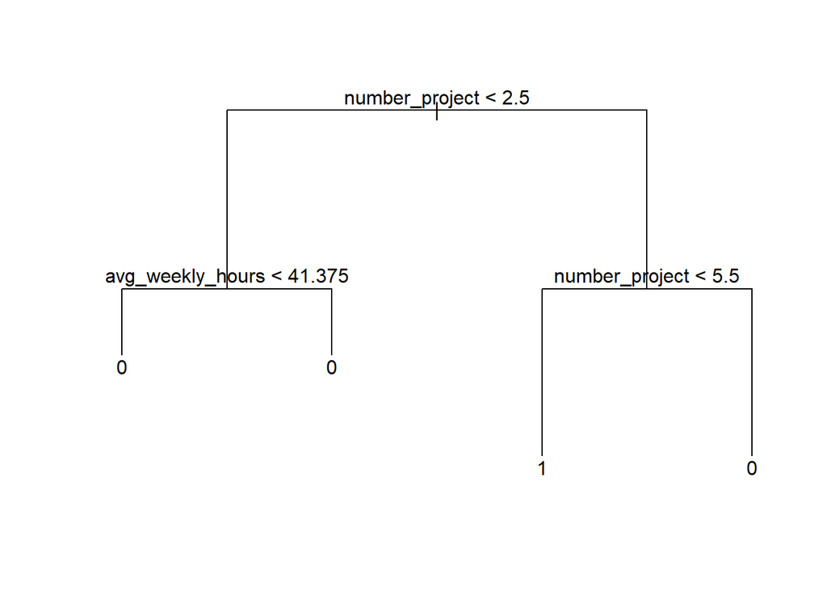

We read the tree as such: When we encounter a split in the branch, we ask if the variable name is greater than the value presented (in this case, does the number of projects exceed 2.5). If the answer is yes, we take the right branch. If the answer is no, we take the left branch. This process is repeated until we reach the terminal nodes. Just from looking the tree, it looks like number of projects and average weekly hours are variables that the model believes are important in predicting employee satisfaction. As an example, the way that we would read this tree is that if an employee is working on more than over 2.5 projects, and they are working on more than 5.5 projects, the model would predict that we would get a value of zero given those inputs.

We can also use cross validation to improve our tree model as such:

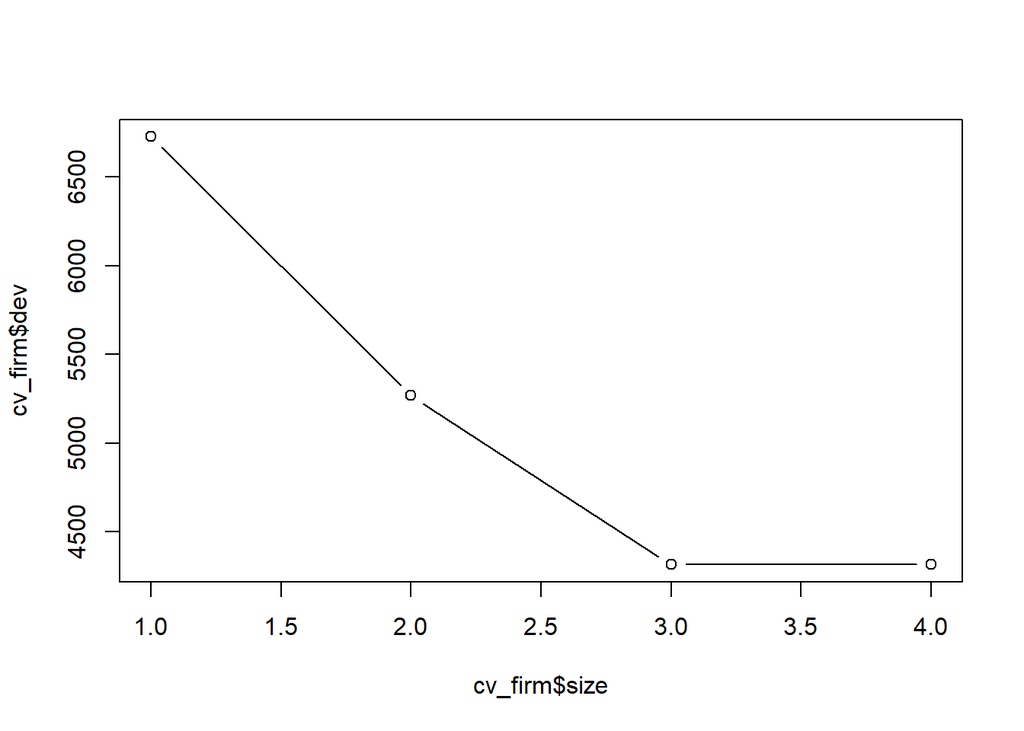

This is a graph of the size of our tree on the x-axis, and our model error on the y-axis. It looks like when our model has four terminal nodes to predict our data, that is where the error is lowest. Conveniently, our original model already had that. Lets look at how well our model did in predicting the outcome variable by putting in a confusion matrix:

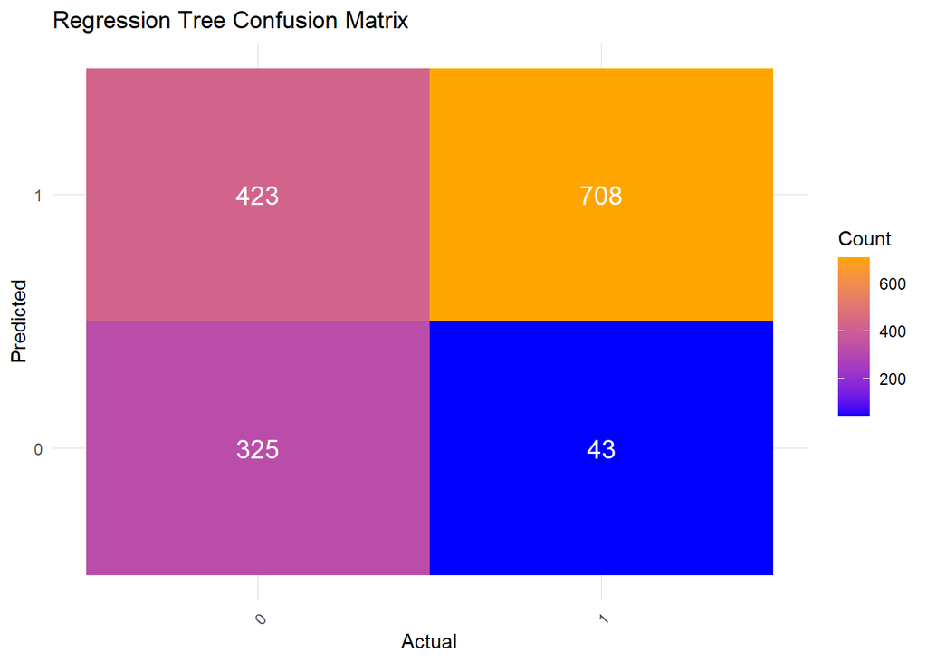

Our model has a 68.9% Classification rate, so only slightly better than K-nearest neighbors. One downside of regression trees is that they are prone to overfitting. This means that our model follows the noise in the training data too closely rather than picking up general patterns. There is another tree based method that we can use that addresses this concern, however.

## Random Forest

Random forests are another tree-based machine learning method where we are combining the output of multiple decision trees to reach a single result. The way that random forests solves the overfitting problem of regression trees is that the algorithm is generating a large number of bootstrapped data sets. This essentially means that we are creating mini data sets from our original data set (with replacement, meaning that the same value can be represented multiple times) to train our model on. This is a way that we can avoid overfitting our model.

Lets try it out!

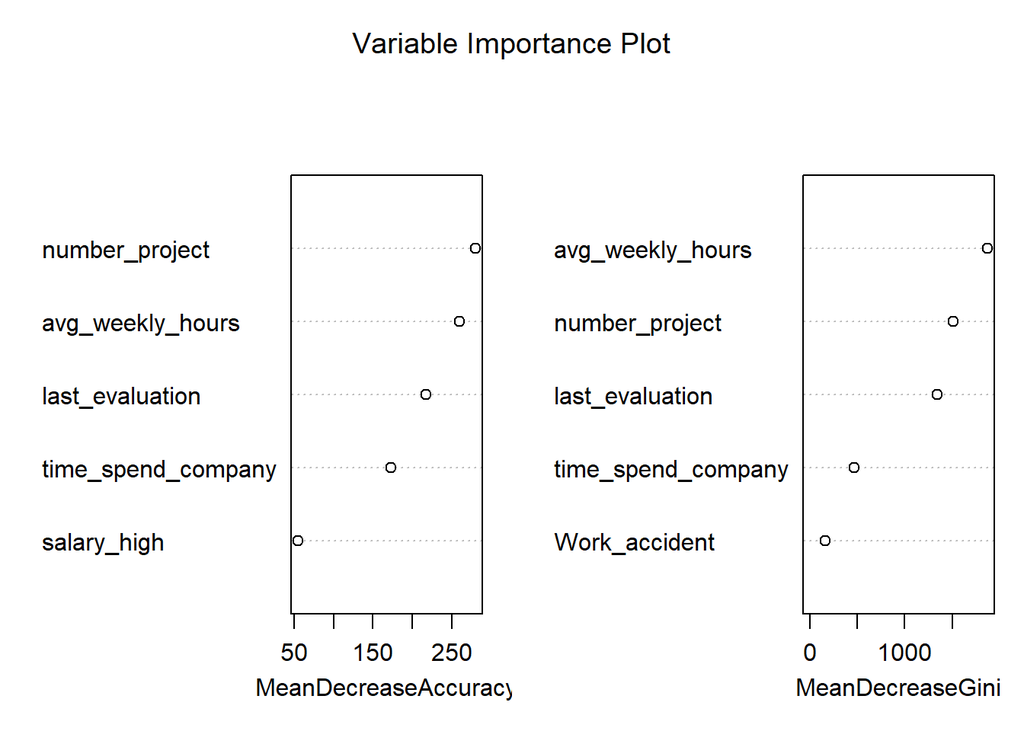

This is a variable importance plot and it uses two metrics to measure the importance of the variables in the model. The left plot measures the mean decrease in accuracy. This plot visualizes the mean change in accuracy if you were to remove a variable from the model. The mean gini decrease is another measure that looks at the predictive power of the variables in our model. In both plots, number of projects and average weekly hours seem to have strong predictive power in our model. If we were to remove those two features from the model, the model accuracy would suffer greatly.

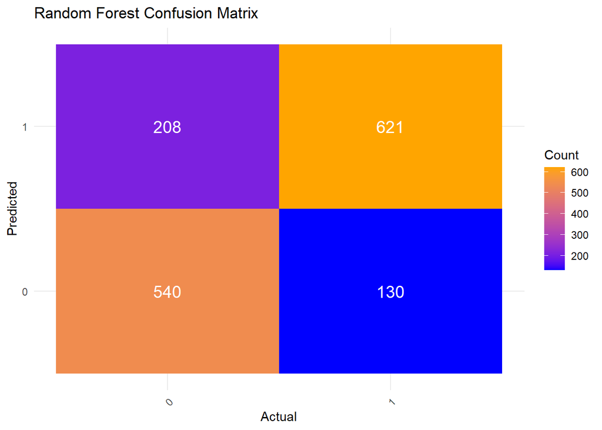

After training the model and applying the test data, we can see that the random forest has a 77% classification rate. This is a substantial improvement from the other two models. We are getting a clearer idea as to what factors contribute to workplace satisfaction. Let’s see if our last model can allow us to see this relationship further.

## XGBoost

XGBoost (extreme gradient boosting) is an incredibly flexible algorithm that we can use to predict employee satisfaction. The specifics of the algorithm are quite complicated, but we are using a mix of multiple decision trees to lower the error of our model.

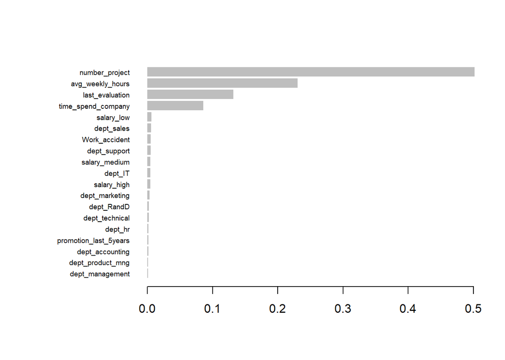

Above is an importance plot that shows the importance of each variable in the model. From the graph, it looks like number of projects and average weekly hours play a significant role in predicting employee satisfaction. Let’s visualize this further with a SHAP plot.

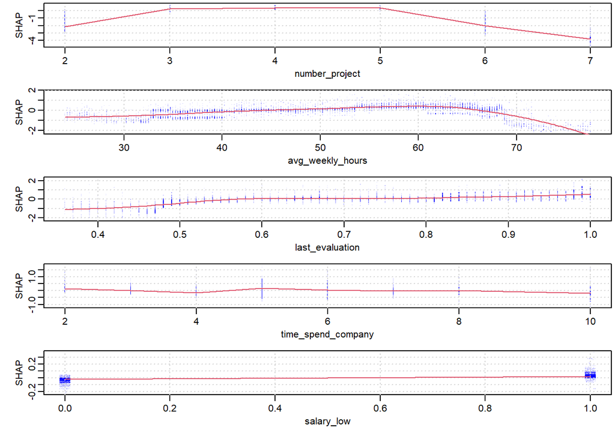

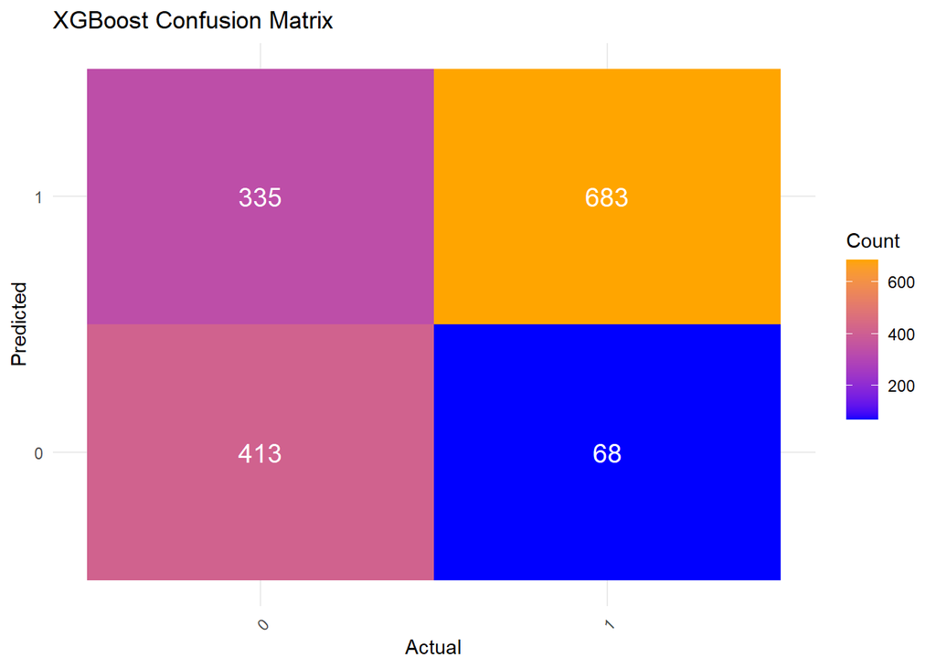

And lastly, here is our confusion matrix for the XGBoost model. The model has a 73% prediction rate. So it is better than K-Nearest-Neighbors and regression trees, but slightly worse than random forest.

## Conclusion

I hope that this project has been able to show you how different factors influence employee satisfaction at a firm. If I were to give this firm recommendations based on what I found, I would recommend them to:

- Find a way to distribute work projects more evenly among employees
- Establish a ceiling of how many hours employees can work
- Put programs in place to encourage employees with lower prior evaluation scores

Thank you for reading!